# Lecture 4: Functions of Random Variables, Linearity, Variance

Author

Jamie Haddock

## A linear function of a random variable

Let $C$ be a random variable — today’s high temperature in Celsius, say, with some PMF $p_C$. In Fahrenheit,
$$F = g(C) = \frac{9}{5}C + 32.$$
$F$ is a new random variable on the *same* sample space as $C$, defined by $F(\omega) = g(C(\omega))$.

## The PMF of a transformed RV

If $g$ is **one-to-one** (invertible) on the range of $X$, the PMF of $Y = g(X)$ is easy:
$$p_Y(y) = P(Y=y) = P(g(X)=y) = P\big(X = g^{-1}(y)\big) = p_X\big(g^{-1}(y)\big).$$

For Fahrenheit, $g^{-1}(f) = \tfrac59(f-32)$, so $p_F(f) = p_C\!\left(\tfrac59(f-32)\right)$ — the probabilities don’t change, only the labels on the axis do.

## LOTUS: the Law Of The Unconscious Statistician

What if we only want $E[Y]$ for $Y = g(X)$, and $g$ *isn’t* one-to-one — so finding $p_Y$ takes real work (recall grouping outcomes by value, as we did for the dice-game payout in Lecture 3)?

**Theorem: LOTUS**

For a discrete RV $X$ and any function $g$,
$$E[g(X)] = \sum_x g(x)\, p_X(x).$$

The name is a joke: it feels too good to be true, but it is!

## Distributions

**Definition: Distribution**

The **distribution** of a random variable $X$ describes how the total probability (which always sums to $1$) is spread out across the values $X$ can take. Formally, it’s specified by giving $P(X \in B)$ for every relevant subset $B$ of values that $X$ can take (or more generally, every subset $B \subset \mathbb{R}$).

For a **discrete** RV, the distribution is fully captured by the PMF $p_X(x) = P(X=x)$ — knowing $p_X$ at every possible value tells you $P(X\in B)$ for any $B$, just by summing. (For RVs with uncountably many values, a PMF alone won’t do — we’ll need new tools, coming in a later lecture.)

## LOTUS example 1: the dice-game payout, revisited

Recall $X$ = die roll (uniform on $\{1,\dots,6\}$), and $Y=g(X)$ pays $2 on even, $-\$1$ on odd. In Lecture 3 we found $p_Y$ first, then computed $E[Y]$. LOTUS skips straight to the answer:
$$E[Y] = \sum_{x=1}^{6} g(x)\cdot \frac16 = - \frac16 + \frac26 - \frac16 + \frac26 - \frac16 + \frac26 = \frac12.$$

## LOTUS example 2: randomized Kaczmarz, revisited

Recall randomized Kaczmarz (RK), solving $Ax = b$: at each step we sample a row index $I \in \{1,\dots,m\}$ at random and update
$$x_{k+1} = x_k + \frac{b_I - a_I^\top x_k}{\lVert a_I \rVert^2}\, a_I .$$

A popular distribution over the rows is the **row-norm PMF** $p_I(i) = \|a_i\|^2/\|A\|_F^2$. We’ll see why now!

Fix the current iterate $x_k$ and let $v = x_k - x^\star$. LOTUS lets us compute the expected value of *any* function of $I$ straight from $p_I$ — for instance
$$E\!\left[\frac{(a_I^\top v)^2}{\|a_I\|^2}\right] = \sum_{i=1}^m \frac{(a_i^\top v)^2}{\|a_i\|^2}\, p_I(i).$$

Plugging in $p_I(i) = \|a_i\|^2/\|A\|_F^2$, the $\|a_i\|^2$ cancels:
$$\sum_{i=1}^m \frac{(a_i^\top v)^2}{\|a_i\|^2}\cdot\frac{\|a_i\|^2}{\|A\|_F^2}
= \frac{1}{\|A\|_F^2}\sum_{i=1}^m (a_i^\top v)^2 = \frac{\|Av\|^2}{\|A\|_F^2}.$$

If $I$ were sampled **uniformly** instead, the $\|a_i\|^2$ would *not* cancel, and the final form wouldn’t be so nice and simple!

## Linearity of expectation

**Theorem: Linearity of expectation**

For random variables $X,Y$ on the same probability space — **possibly dependent** — and constants $a,b,c$:
$$E[aX+bY+c] = aE[X]+bE[Y]+c.$$

**No independence required!**

This holds *no matter how $X$ and $Y$ are related*. It’s what makes linearity of expectation so powerful. (Variance will not be so forgiving — stay tuned.)

## The mean of a Binomial, the slick way

Recall from Lecture 3 we derived $E[X]=np$ for $X\sim\text{Binomial}(n,p)$ via a combinatorial identity. Linearity gives a one-line proof instead.

**Definition: Indicator random variable**

For an event $A$, the indicator $\mathbf 1_A$ equals $1$ if $A$ occurs, $0$ otherwise. Note $E[\mathbf 1_A] = 1\cdot P(A) + 0\cdot P(A^c) = P(A)$.

**Definition: i.i.d.**

Random variables $X_1,\dots,X_n$ are **independent and identically distributed (i.i.d.)** if they are mutually independent and all share the same distribution.

Write binomial random variable $X = \sum_{i=1}^n X_i$, where $X_i = \mathbf 1_{\{\text{trial } i \text{ succeeds}\}}$ — i.i.d. Bernoulli($p$) indicators. By linearity (independence isn’t even needed here!):
$$E[X] = \sum_{i=1}^n E[X_i] = \sum_{i=1}^n p = np.$$

## Linearity also applies to functions of $X$ and $Y$

Combining LOTUS with linearity, for any functions $g,h$:
$$E[g(X) + h(Y)] = E[g(X)] + E[h(Y)].$$

We’ll use exactly this form below.

## The coupon collector problem

There are $n$ distinct coupon types; each box of cereal contains one coupon, uniformly random among the $n$ types, independent of previous boxes. Let $T$ = number of boxes you need to buy in order to collect all $n$ types of coupons. What’s $E[T]$?

Write $T = T_1+T_2+\cdots+T_n$, where $T_i$ = number of *additional* boxes needed to find a new type, right after collecting the $(i-1)$-th distinct type. With $i-1$ types already in hand, each new box is a new type with probability $p_i = \frac{n-i+1}{n}$, so $T_i\sim\text{Geometric}(p_i)$ and $E[T_i] = \frac{n}{n-i+1}$.

By linearity,
$$E[T] = \sum_{i=1}^n E[T_i] = \sum_{i=1}^n \frac{n}{n-i+1} = n\sum_{k=1}^n \frac1k = nH_n \approx n\ln n.$$

```python
import numpy as np

def collect_coupons(n, rng):
    seen = set()
    draws = 0
    while len(seen) < n:
        seen.add(rng.integers(n))
        draws += 1
    return draws

rng = np.random.default_rng(151)
n = 20
trials = 3000
results = [collect_coupons(n, rng) for _ in range(trials)]

H_n = sum(1 / k for k in range(1, n + 1))
print(f"n = {n}")
print(f"simulated average T over {trials} trials: {np.mean(results):.2f}")
print(f"formula n*H_n = {n*H_n:.2f}")
```

```
n = 20
simulated average T over 3000 trials: 72.50
formula n*H_n = 71.95
```

## Linearity + LOTUS: average one-step progress of RK

Recall randomized Kaczmarz’s update, and note that the Pythagorean theorem (the update is an orthogonal projection) provides,
$$\|x_{k+1}-x^\star\|^2 = \|v\|^2 - \frac{(a_I^\top v)^2}{\|a_I\|^2}.$$
where $v = x_k-x^\star$.

$\|v\|^2$ is a **constant** given $x_k$ — only $I$ is random. By linearity,
$$E\big[\|x_{k+1}-x^\star\|^2\big]
= \|v\|^2 - E\!\left[\frac{(a_I^\top v)^2}{\|a_I\|^2}\right]
= \|v\|^2 - \frac{\|Av\|^2}{\|A\|_F^2},$$
reusing the LOTUS computation from a few slides ago!

Since $\|Av\| \ge \sigma_{\min}(A)\|v\|$,
$$E\big[\|x_{k+1}-x^\star\|^2\big] \;\le\; \left(1 - \frac{\sigma_{\min}(A)^2}{\|A\|_F^2}\right)\|x_k-x^\star\|^2.$$
Every step shrinks the *expected* squared error by a fixed factor — this a very nice (and very well-cited) result from Thomas Strohmer and Roman Vershynin in 2009!

## Watching the bound play out over many steps

The one-step bound says the expected squared error shrinks by a fixed factor *every* step. Let’s actually run RK and watch $\|x_k-x^\star\|^2$ fall, averaged over many independent random runs.

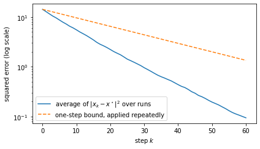

```python
import numpy as np
import matplotlib.pyplot as plt

rng = np.random.default_rng(151)
m, n = 20, 8
A = rng.standard_normal((m, n))
x_star = rng.standard_normal(n)
b = A @ x_star
row_norm_sq = (A ** 2).sum(axis=1)
p_row_norm = row_norm_sq / row_norm_sq.sum()
sigma_min = np.linalg.svd(A, compute_uv=False)[-1]
frob_sq = row_norm_sq.sum()

num_steps = 60
num_runs = 300
errors_sq = np.zeros((num_runs, num_steps + 1))

for r in range(num_runs):
    x = np.zeros(n)
    errors_sq[r, 0] = np.linalg.norm(x - x_star) ** 2
    idx_sequence = rng.choice(m, size=num_steps, p=p_row_norm)
    for t, i in enumerate(idx_sequence, start=1):
        a_i, b_i = A[i], b[i]
        x = x + (b_i - a_i @ x) / row_norm_sq[i] * a_i
        errors_sq[r, t] = np.linalg.norm(x - x_star) ** 2

mean_error_sq = errors_sq.mean(axis=0)
bound_curve = errors_sq[:, 0].mean() * (1 - sigma_min**2 / frob_sq) ** np.arange(num_steps + 1)

fig, ax = plt.subplots(figsize=(6, 3.5))
ax.semilogy(mean_error_sq, label="average of $\\|x_k-x^\\star\\|^2$ over runs")
ax.semilogy(bound_curve, "--", label="one-step bound, applied repeatedly")
ax.set_xlabel("step $k$")
ax.set_ylabel("squared error (log scale)")
ax.legend()
plt.tight_layout()
plt.show()
```

## Moments

**Definition: Moments**

The $k$-th moment of a random variable $X$ is $E[X^k]$. The mean $E[X]$ is the 1st moment. The 2nd moment, $E[X^2]$, is about to become useful.

## Why do we need more than the mean?

Suppose you only know $E[X]$ where $X = \|x_k-x^\star\|^2$ is small (e.g., from the bound we just derived). What does that tell you about the error on *any one particular run* of RK iterations?

**Not much, on its own!** The mean is an average over all randomness; a single run could still land far from it. To say anything about how *spread out* outcomes are around the mean, we need a new tool: **variance**.

**Aside: the probabilistic method**

Expectation alone *can* still be a powerful existence tool: if $E[X]\le c$, then *some* outcome $\omega$ must satisfy $X(\omega)\le c$ (otherwise every outcome would exceed $c$, forcing $E[X]>c$). This “probabilistic method” is often used to prove existence results in combinatorics — but it says nothing about *how many* outcomes are near $c$, or how far the rest can stray. That’s what variance is for.

## Variance and standard deviation

**Definition: Variance**

$$\mathrm{Var}(X) = E\big[(X-E[X])^2\big].$$
The **standard deviation** is $\sigma_X = \sqrt{\mathrm{Var}(X)}$ — same units as $X$ itself (variance is in squared units), which is often why it’s the more interpretable number.

## Variance of a linear function

For constants $a,b$:
$$\mathrm{Var}(aX+b) = a^2\,\mathrm{Var}(X).$$

**Proof:** $E[aX+b] = aE[X]+b$, so
$$\mathrm{Var}(aX+b) = E\big[(aX+b-aE[X]-b)^2\big] = E\big[a^2(X-E[X])^2\big] = a^2\,\mathrm{Var}(X).$$
The additive shift $b$ vanishes entirely — variance sees only *spread*, never *location*.

## Variance shortcut formula

**Theorem**

$$\mathrm{Var}(X) = E[X^2] - \big(E[X]\big)^2.$$

**Proof:** expand $(X-E[X])^2 = X^2-2XE[X]+(E[X])^2$ and take $E[\cdot]$, using linearity (note $E[X]$ is a constant):
$$E\big[(X-E[X])^2\big] = E[X^2]-2E[X]E[X]+(E[X])^2 = E[X^2]-(E[X])^2.$$
This is almost always the easiest way to *compute* a variance.

## Compute $\mathrm{Var}(X)$ for each named distribution

**Bernoulli($p$):** $X^2=X$ on $\{0,1\}$, so $E[X^2]=E[X]=p$, giving $\mathrm{Var}(X)=p-p^2=p(1-p)$.

**Rademacher:** $X^2=1$ always, so $E[X^2]=1$, $E[X]=0$, giving $\mathrm{Var}(X)=1$.

**In-class activity**

Using $\mathrm{Var}(X)=E[X^2]-(E[X])^2$, compute $\mathrm{Var}(X)$ for Geometric and Poisson.

**Geometric($p$):** Using the derivative series trick twice gives $E[X^2]=\dfrac{2-p}{p^2}$, so
$$\mathrm{Var}(X) = \frac{2-p}{p^2}-\frac1{p^2} = \frac{1-p}{p^2}.$$

**Poisson($\lambda$):** $E[X^2]=\lambda^2+\lambda$, which gives
$$\mathrm{Var}(X) = \lambda^2+\lambda-\lambda^2 = \lambda.$$
(Poisson is the rare distribution with mean $=$ variance!)

## Variance of a sum — independence *is* required this time

**Contrast with linearity of expectation**

$E[X+Y]=E[X]+E[Y]$ *always*. But in general $\mathrm{Var}(X+Y)\ne\mathrm{Var}(X)+\mathrm{Var}(Y)$ — cross terms from how $X$ and $Y$ move together get in the way.

**Theorem**

If $X_1,\dots,X_n$ are **independent**, then
$$\mathrm{Var}\!\left(\sum_{i=1}^n X_i\right) = \sum_{i=1}^n \mathrm{Var}(X_i).$$

**Payoff:** writing Binomial($n,p$) as a sum of $n$ i.i.d. Bernoulli($p$) indicators:
$$\mathrm{Var}(X) = \sum_{i=1}^n \mathrm{Var}(X_i) = np(1-p).$$

## Central moments

**Definition: Central moments**

The $k$-th **central moment** of $X$ is $E[(X-E[X])^k]$ — an ordinary moment, but centered at the mean first.

- The 1st central moment is always $0$ (by definition of the mean).
- The **2nd central moment is exactly the variance** — nothing new, just a name.
- Higher central moments capture other shape features: the 3rd relates to *skewness* (asymmetry), the 4th to *kurtosis* (tail heaviness). We won’t need these in this course, but variance is really just the first member of this whole family.